# Análisis Exploratorio

GRUPO 6

2/1/2021

# Hoja de Trabajo #1

En este informe usted podrá leer los hallazgos de EDA.

### Descripción del conjunto de datos

El conjunto de datos está compuesto por

```
## [1] 10866
```

observaciones de

```
## [1] 21
```

variables.

```
##        id           imdb_id            popularity           budget
##  Min.   :     5   Length:10866       Min.   : 0.00006   Min.   :        0
##  1st Qu.: 10596   Class :character   1st Qu.: 0.20758   1st Qu.:        0
##  Median : 20669   Mode  :character   Median : 0.38386   Median :        0
##  Mean   : 66064                      Mean   : 0.64644   Mean   : 14625701
##  3rd Qu.: 75610                      3rd Qu.: 0.71382   3rd Qu.: 15000000
##  Max.   :417859                      Max.   :32.98576   Max.   :425000000
##     revenue          original_title         cast             homepage
##  Min.   :0.000e+00   Length:10866       Length:10866       Length:10866
##  1st Qu.:0.000e+00   Class :character   Class :character   Class :character
##  Median :0.000e+00   Mode  :character   Mode  :character   Mode  :character
##  Mean   :3.982e+07
##  3rd Qu.:2.400e+07
##  Max.   :2.782e+09
##    director           tagline            keywords           overview
##  Length:10866       Length:10866       Length:10866       Length:10866
##  Class :character   Class :character   Class :character   Class :character
##  Mode  :character   Mode  :character   Mode  :character   Mode  :character
##
##
##
##     runtime         genres          production_companies release_date
##  Min.   :  0.0   Length:10866       Length:10866         Length:10866
##  1st Qu.: 90.0   Class :character   Class :character     Class :character
##  Median : 99.0   Mode  :character   Mode  :character     Mode  :character
##  Mean   :102.1
##  3rd Qu.:111.0
##  Max.   :900.0
##    vote_count      vote_average    release_year    budget_adj
##  Min.   :  10.0   Min.   :1.500   Min.   :1960   Min.   :        0
##  1st Qu.:  17.0   1st Qu.:5.400   1st Qu.:1995   1st Qu.:        0
##  Median :  38.0   Median :6.000   Median :2006   Median :        0
##  Mean   : 217.4   Mean   :5.975   Mean   :2001   Mean   : 17551040
##  3rd Qu.: 145.8   3rd Qu.:6.600   3rd Qu.:2011   3rd Qu.: 20853251
##  Max.   :9767.0   Max.   :9.200   Max.   :2015   Max.   :425000000
##   revenue_adj
##  Min.   :0.000e+00
##  1st Qu.:0.000e+00
##  Median :0.000e+00
##  Mean   :5.136e+07
##  3rd Qu.:3.370e+07
##  Max.   :2.827e+09
```

Las variables y su tipo dentro del data set son:

```
## 'data.frame':    10866 obs. of  21 variables:
##  $ id                  : int  135397 76341 262500 140607 168259 281957 87101 286217 211672 150540 ...
##  $ imdb_id             : chr  "tt0369610" "tt1392190" "tt2908446" "tt2488496" ...
##  $ popularity          : num  32.99 28.42 13.11 11.17 9.34 ...
##  $ budget              : int  150000000 150000000 110000000 200000000 190000000 135000000 155000000 108000000 74000000 175000000 ...
##  $ revenue             : num  1.51e+09 3.78e+08 2.95e+08 2.07e+09 1.51e+09 ...
##  $ original_title      : chr  "Jurassic World" "Mad Max: Fury Road" "Insurgent" "Star Wars: The Force Awakens" ...
##  $ cast                : chr  "Chris Pratt|Bryce Dallas Howard|Irrfan Khan|Vincent D'Onofrio|Nick Robinson" "Tom Hardy|Charlize Theron|Hugh Keays-Byrne|Nicholas Hoult|Josh Helman" "Shailene Woodley|Theo James|Kate Winslet|Ansel Elgort|Miles Teller" "Harrison Ford|Mark Hamill|Carrie Fisher|Adam Dr…
##  $ homepage            : chr  "http://www.jurassicworld.com/" "http://www.madmaxmovie.com/" "http://www.thedivergentseries.movie/#insurgent" "http://www.starwars.com/films/star-wars-episode-vii" ...
##  $ director            : chr  "Colin Trevorrow" "George Miller" "Robert Schwentke" "J.J. Abrams" ...
##  $ tagline             : chr  "The park is open." "What a Lovely Day." "One Choice Can Destroy You" "Every generation has a story." ...
##  $ keywords            : chr  "monster|dna|tyrannosaurus rex|velociraptor|island" "future|chase|post-apocalyptic|dystopia|australia" "based on novel|revolution|dystopia|sequel|dystopic future" "android|spaceship|jedi|space opera|3d" ...
##  $ overview            : chr  "Twenty-two years after the events of Jurassic Park, Isla Nublar now features a fully functioning dinosaur theme"| __truncated__ "An apocalyptic story set in the furthest reaches of our planet, in a stark desert landscape where humanity is b"| __truncated__ "Beatrice…
##  $ runtime             : int  124 120 119 136 137 156 125 141 91 94 ...
##  $ genres              : chr  "Action|Adventure|Science Fiction|Thriller" "Action|Adventure|Science Fiction|Thriller" "Adventure|Science Fiction|Thriller" "Action|Adventure|Science Fiction|Fantasy" ...
##  $ production_companies: chr  "Universal Studios|Amblin Entertainment|Legendary Pictures|Fuji Television Network|Dentsu" "Village Roadshow Pictures|Kennedy Miller Productions" "Summit Entertainment|Mandeville Films|Red Wagon Entertainment|NeoReel" "Lucasfilm|Truenorth Productions|Bad Robot" ...
##  $ release_date        : chr  "6/9/15" "5/13/15" "3/18/15" "12/15/15" ...
##  $ vote_count          : int  5562 6185 2480 5292 2947 3929 2598 4572 2893 3935 ...
##  $ vote_average        : num  6.5 7.1 6.3 7.5 7.3 7.2 5.8 7.6 6.5 8 ...
##  $ release_year        : int  2015 2015 2015 2015 2015 2015 2015 2015 2015 2015 ...
##  $ budget_adj          : num  1.38e+08 1.38e+08 1.01e+08 1.84e+08 1.75e+08 ...
##  $ revenue_adj         : num  1.39e+09 3.48e+08 2.72e+08 1.90e+09 1.39e+09 ...
```

Los histogramas para comprobar normalidad en los datos cuantitativos de los data sets son los siguientes.

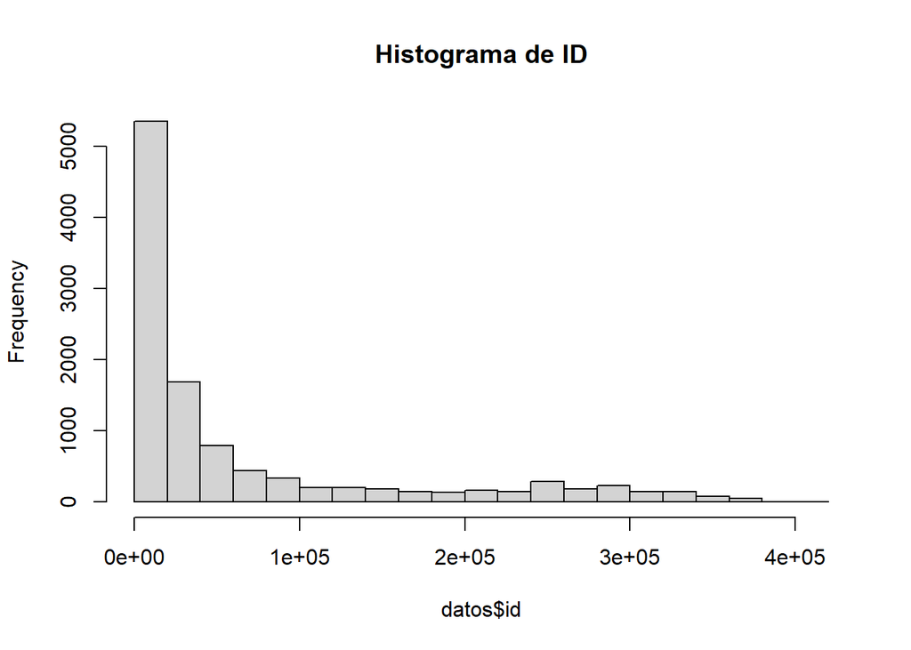

```r
hist(x= datos$id, main=paste("Histograma de ID"))
```

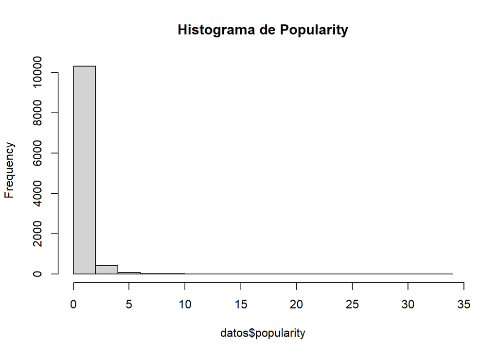

```r
hist(x= datos$popularity, main=paste("Histograma de Popularity"))
```

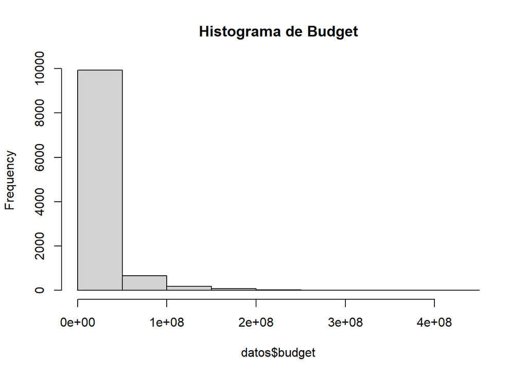

```r
hist(x= datos$budget, main=paste("Histograma de Budget"))
```

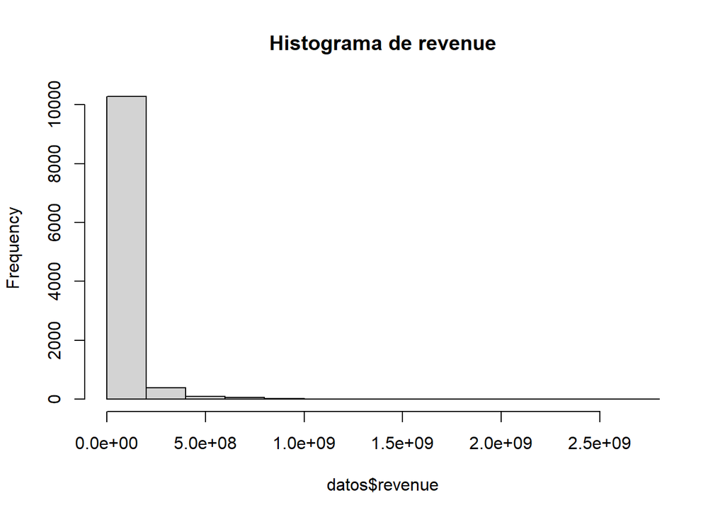

```r
hist(x= datos$revenue, main=paste("Histograma de revenue"))
```

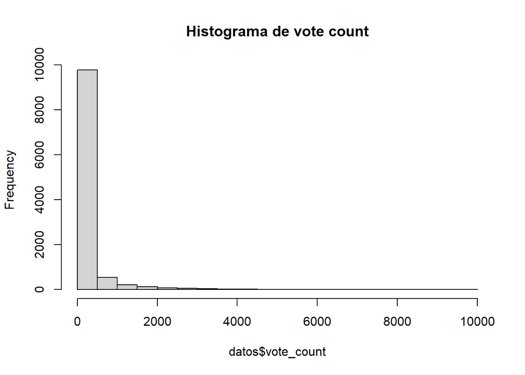

```r
hist(x= datos$vote_count, main=paste("Histograma de vote count"))
```

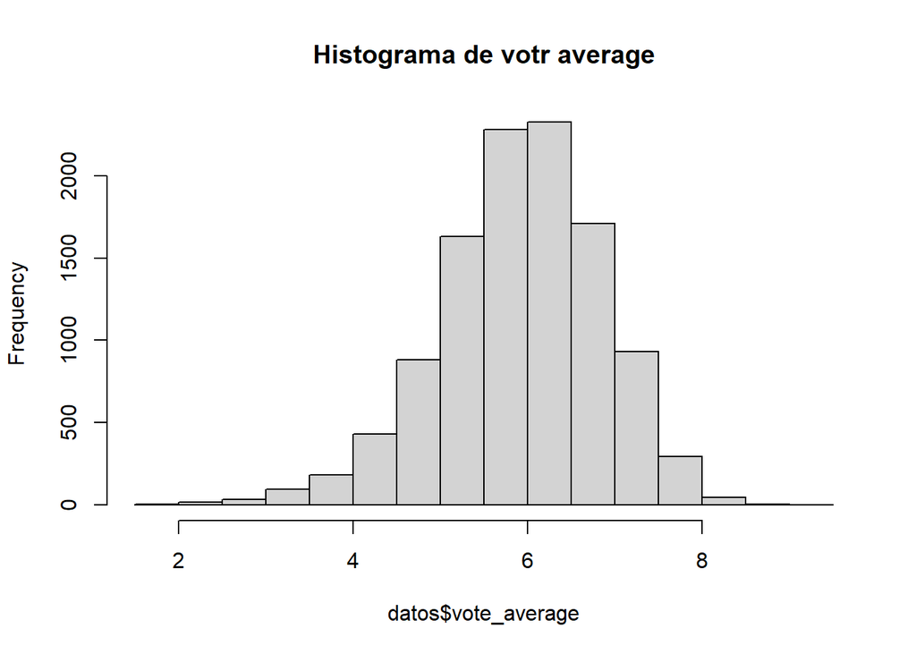

```r
hist(x= datos$vote_average, main=paste("Histograma de votr average"))
```

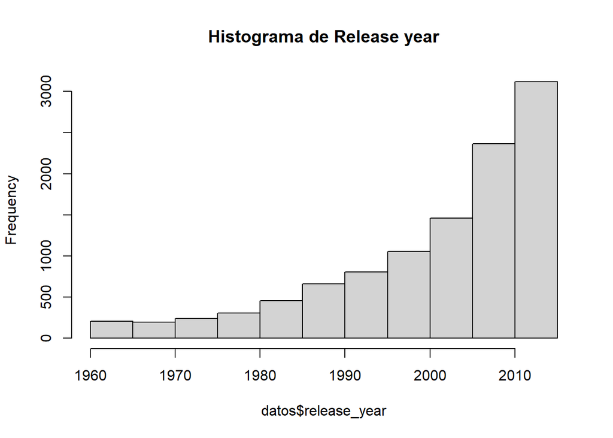

```r
hist(x= datos$release_year, main=paste("Histograma de Release year"))
```

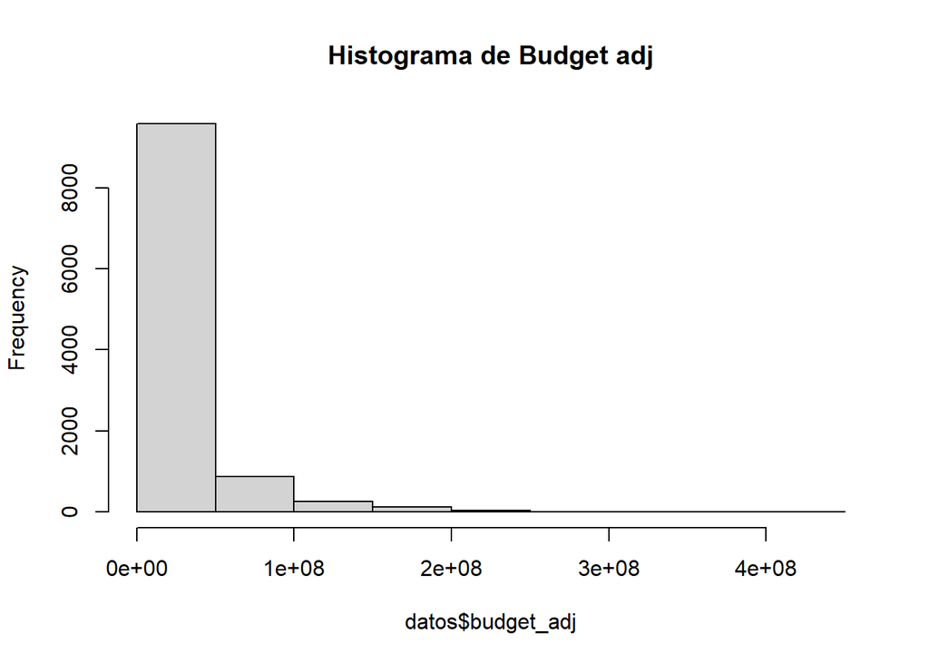

```r
hist(x= datos$budget_adj, main=paste("Histograma de Budget adj"))
```

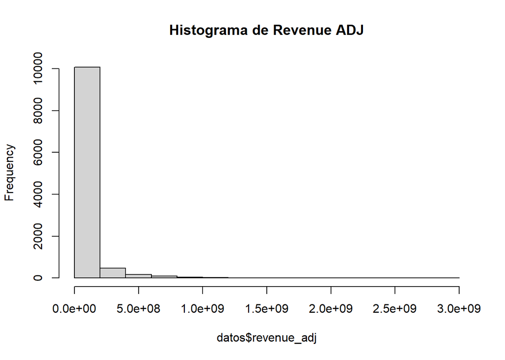

```r
hist(x= datos$revenue_adj, main=paste("Histograma de Revenue ADJ"))
```

Para tablas de frecuencias de las variables cualitativas se se mostraran las líneas de código ya que los resultados de algunas toman muchos espacio, las lineas de código son las siguientes son las siguientes:

## imbd_id

`IMBD_ID <- c(datos$imdb_id) table(IMBD_ID)`

## cast

`cast <- c(datos$cast) table(cast)`

## homepage

`hp <- c(datos$homepage) table(hp)`

## director

`director <- c(datos$director) table(director)`

## tagline

`tagline <- (datos$tagline) table (tagline)`

##¿Cuáles son las 10 películas que contaron con más presupuesto?

```r
library(tidyverse)
datos %>% top_n(10, datos$budget)
```

```
##        id   imdb_id popularity    budget    revenue
## 1   99861 tt2395427   5.944927 280000000 1405035767
## 2  122917 tt2310332  10.174599 250000000  955119788
## 3  127585 tt1877832   6.052479 250000000  746000000
## 4     767 tt0417741   5.076472 250000000  933959197
## 5   12444 tt0926084   4.840588 250000000  954305868
## 6   38757 tt0398286   2.865684 260000000  591794936
## 7   46528 tt1032751   0.250540 425000000   11087569
## 8    1865 tt1298650   4.955130 380000000 1021683000
## 9   49026 tt1345836   6.591277 250000000 1081041287
## 10  49051 tt0903624   4.218933 250000000 1017003568
## 11  49529 tt0401729   1.588457 260000000  284139100
## 12  57158 tt1170358   4.310786 250000000  958400000
## 13  57201 tt1210819   1.214510 255000000   89289910
## 14   1452 tt0348150   1.957331 270000000  391081192
```

[output cut: 172 more lines]

##¿Cuáles son las 10 películas que más ingresos tuvieron?

```r
library(tidyverse)
datos %>% top_n(10, datos$revenue)
```

```
##        id   imdb_id popularity    budget    revenue
## 1  135397 tt0369610  32.985763 150000000 1513528810
## 2  140607 tt2488496  11.173104 200000000 2068178225
## 3  168259 tt2820852   9.335014 190000000 1506249360
## 4   99861 tt2395427   5.944927 280000000 1405035767
## 5   19995 tt0499549   9.432768 237000000 2781505847
## 6   12445 tt1201607   5.711315 125000000 1327817822
## 7   24428 tt0848228   7.637767 220000000 1519557910
## 8     597 tt0120338   4.355219 200000000 1845034188
## 9  109445 tt2294629   6.112766 150000000 1274219009
## 10  68721 tt1300854   4.946136 200000000 1215439994
##                                  original_title
## 1                                Jurassic World
## 2                  Star Wars: The Force Awakens
## 3                                     Furious 7
```

[output cut: 95 more lines]

##¿Cuál es la película que más votos tuvo?

```r
datos[which.max(datos$vote_count),]
```

```
##         id   imdb_id popularity    budget   revenue original_title
## 1920 27205 tt1375666   9.363643 160000000 825500000      Inception
##                                                                          cast
## 1920 Leonardo DiCaprio|Joseph Gordon-Levitt|Ellen Page|Tom Hardy|Ken Watanabe
##                                   homepage          director
## 1920 http://inceptionmovie.warnerbros.com/ Christopher Nolan
##                                   tagline
## 1920 Your mind is the scene of the crime.
##                                              keywords
## 1920 loss of lover|dream|sleep|subconsciousness|heist
##                                                                                                                                                                                                                                                                                      overview
## 1920 Cobb, a skilled thief who commits corporate espionage by infiltrating the subconscious of his targets is offered a chance to regain his old life as payment for a task considered to be impossible: "inception", the implantation of another person's idea into a target's subconscious.
##      runtime                                            genres
## 1920     148 Action|Thriller|Science Fiction|Mystery|Adventure
##                         production_companies release_date vote_count
## 1920 Legendary Pictures|Warner Bros.|Syncopy      7/14/10       9767
##      vote_average release_year budget_adj revenue_adj
## 1920          7.9         2010    1.6e+08   825500000
```

##¿Cuál es la peor película de acuerdo a los votos de todos los usuarios?

```r
datos[which.min(datos$vote_count),]
```

```
##         id   imdb_id popularity budget revenue original_title
## 241 363689 tt4229298     0.5327      0       0   The Unspoken
##                                                                          cast
## 241 Jodelle Ferland|Sunny Suljic|Neal McDonough|Matt Bellefleur|Fulvio Cecere
##     homepage       director tagline keywords
## 241          Sheldon Wilson
##                                                                                                                                                                                                                                                                                                          …
## 241 In 1997 the close-knit Anderson family vanished from their home without a trace. No bodies were ever found and no explanation satisfied curiosity. For 17 years the house has remained undisturbed...until now. This eerily expert frightener is further enlivened by terrific performances from Ã¢â‚…
##     runtime          genres                      production_companies
## 241      90 Thriller|Horror Lighthouse Pictures|Sapphire Fire Limited
##     release_date vote_count vote_average release_year budget_adj revenue_adj
## 241     10/24/15         10          4.1         2015          0           0
```

##¿Cuántas películas se hicieron en cada año? ¿En qué año se hicieron  
##más películas? Haga un gráfico de barras

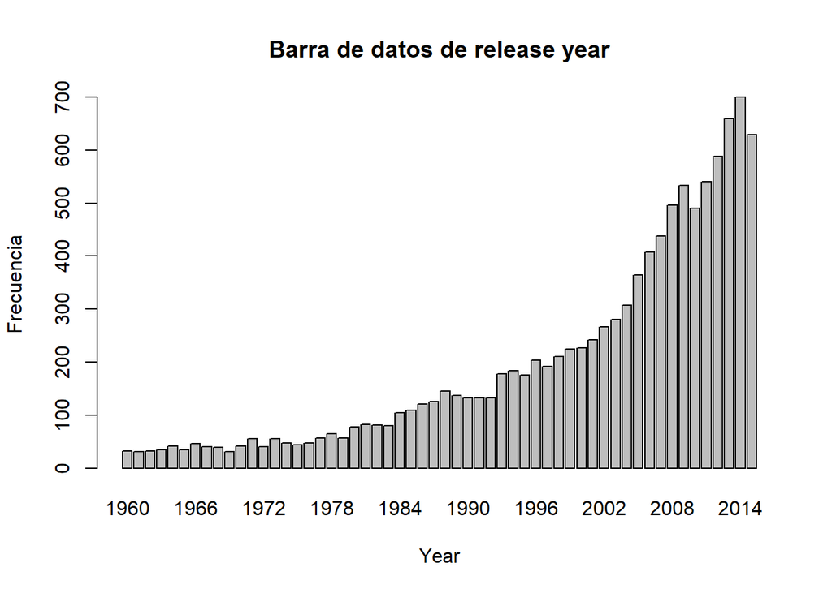

```r
hola <- table(datos$release_year)
barplot(hola,main="Barra de datos de release year",xlab="Year",ylab="Frecuencia")
```

##¿Cuál es el género principal de las 20 películas más populares?

```r
library(tidyverse)
subdatos <- datos %>% top_n(20, datos$popularity)
generos <-(subdatos$genres)
table(generos)
```

```
## generos
##          Action|Adventure|Fantasy|Science Fiction
##                                                 1
##                  Action|Adventure|Science Fiction
##                                                 1
##          Action|Adventure|Science Fiction|Fantasy
##                                                 1
##         Action|Adventure|Science Fiction|Thriller
##                                                 2
##                             Action|Crime|Thriller
##                                                 1
##                  Action|Science Fiction|Adventure
##                                                 1
##                                   Action|Thriller
##                                                 1
## Action|Thriller|Science Fiction|Mystery|Adventure
##                                                 1
##                  Adventure|Action|Science Fiction
##                                                 1
##                   Adventure|Drama|Science Fiction
##                                                 1
##          Adventure|Family|Animation|Action|Comedy
##                                                 1
##                                 Adventure|Fantasy
##                                                 1
##                          Adventure|Fantasy|Action
##                                                 1
##                Adventure|Science Fiction|Thriller
##                                                 1
##                                             Drama
##                                                 1
##                       Drama|Action|Crime|Thriller
##                                                 1
##         Science Fiction|Action|Thriller|Adventure
##                                                 1
##                Science Fiction|Adventure|Thriller
##                                                 1
##                  Western|Drama|Adventure|Thriller
##                                                 1
```

##¿Cuál es el género que predomina en el conjunto de datos?

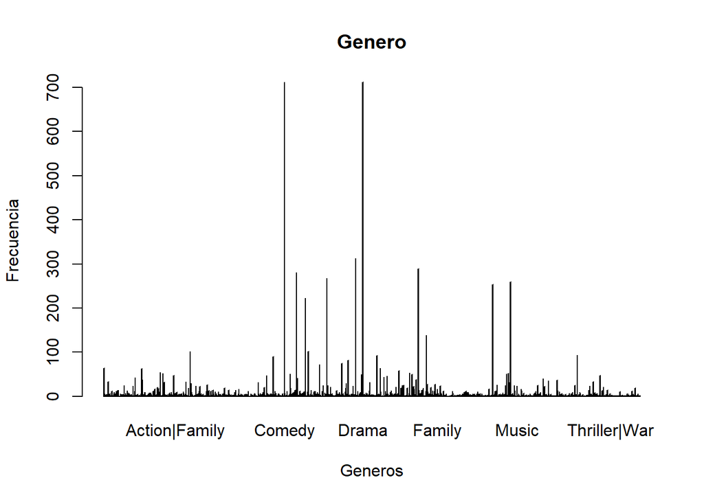

```r
genres <- table(datos$genres)
barplot(genres,main= "Genero",xlab="Generos",ylab="Frecuencia")
```

##¿Las películas de qué género principal obtuvieron mayores ganancias?

[figure not shown]

```r
genres <- table(datos$genres)
ganancias <- table(datos$revenue)
barplot(genres,ganancias,main= "Genero",xlab="Generos",ylab="Ganancias")
```

##¿Las películas de qué género principal necesitaron mayor presupuesto?

[figure not shown]

```r
genres <- table(datos$genres)
presupuesto <- table(datos$budget)
barplot(genres,presupuesto,main= "Genero",xlab="Generos",ylab="Presupuesto")
```

[output not shown]